# Learning about OHI scores

## OH NO!

While you are working at your computer at NCEAS, you receive a frantic call from someone working on an OHI project:

THEY NEED HELP!

“No problem” you say, “I’ll get Julie or Melanie”…but they are no where to be found!

“Hold on, I’ll get Jamie or Casey or Courtney”…but they are also gone.

It is clearly going to be up to you to save the day!!

## You’ve got this!

Please help them answer the following questions. You will work from this document, using the code chunks as a work space to work explore the data. Do NOT bother keeping the code chunks neat and organized, we want to see your work process in all its messy glory. However, I DO recommend including plenty of comments, mostly because I have found this helps me organize my thoughts.

You will work together to check answers, discuss code, troubleshoot. But write your own code.

You can also ask us any questions along the way (slack or issues)!

Good luck!

## Questions

### Getting the data

*Goal* Read the latest OHI global data into the R working space (call the data object “scores”).

*Hint* Here is a link to the data: https://raw.githubusercontent.com/OHI-Science/ohi-global/draft/eez/scores.csv

### Region explore

*Hint 1* Here is a link to the official region list: https://raw.githubusercontent.com/OHI-Science/ohi-global/draft/eez/spatial/regions_list.csv

*Hint 2* Which region has all NA values for scores?

*Answer* Antarctica (Region 213) does not have score data associated with it, and there are data for region_id=0, which is not included in the list of regions linked above (maybe this is the average?)

*Question* Which region id corresponds to the United States?

### Goal explore

*Question* When I look at the number of goals, N=19 show up….I thought there were supposed to be 10 goals!!! Can you explain what all these are? Also, why do some of the goal abbreviations have 2 letters and others 3 letters?

*Hint 1* Review the methods doc here: https://raw.githack.com/OHI-Science/ohi-global/published/global2018/Results/Supplement_Results.html

*Answer* The US is Region ID 163. The 10 main goals have two-letter abbreviations, and the 8 subgoals (not every goal has a subgoal) have three-letter abbreviations. Each regigon also has an associated “Index” score.

### Dimension explore

*Answer* There are more score values than status values, because of the “Index” scores. The Index score for each region does not have a corresponding status value, only a score. This makes there appear to be more score values.

### Missing data

*Question* Figure out which goals/subgoals have the most NA values for scores in 2018. Which ones have the least? Can you discern any reason why some goals have lots of missing values and others do not?

*Hint* Include only dimension = score, and year = 2018, and cut region_id = 0.

*Answer* With 83, the natural products goal had the most NA values in the 2018 scores. The following goals/subgoals all had just one NA value: artisanal fishing, biodiversity, clean waters, fishing, iconic species (sense of place subgoal), lasting special places (sense of place subgoals), and species condition (biodiversity subgoal). Along with natural products, carbon storage and coastal protection had high numbers of NA values. These metrics may be difficult to measure, and analogs may not readily exist for gap-filling the data.

*Question* Artisanal opportunities has no missing data (except for region 213, which is Antarctica). Look over the description of the artisanal opportunities goal (http://ohi-science.org/ohi-global/goals#artisanal_fishing_opportunity). Based on this description, in your opinion, should uninhabited islands be given an NA value?

*Answer* Yes - the score directly assesses the needs of the inhabitants, so if there are no inhabitants, the score should be NA. Further, the values that are incorporated into this score are not relevant for an uninhabited region (economic need, social progress, governance, etc)

### Scores

*Question* If we have a goal with a future status of 80 and status of 90…what is the score?

*Answer* Current and future status are averaged to get the score, so a goal with a future status of 80 and a status of 90 would have a score of 85.

### Metadata

*Project* Based on your data exploration and other resources, provide some metadata that describes each variable. Write it so it would be useful to you in the future as you are looking through these data.

Write it in the following table. NOTE: Knit the document to see if the table is formatting correctly (but don’t bother if you do not know how to knit a document or if you are running into errors!).

[output not shown]

| Goal/Subgoal | Abbreviation | Classification |
| --- | --- | --- |
| Artisanal Fishing Opportunities | AO | Goal |
| Biodiversity | BD | Goal |
| Carbon storage | CS | Goal |
| Coastal livelihoods and economies | LE | Goa |
| Coastal protection | CP | Goal |
| Clean waters | CW | Goal |
| Economies | ECO | Subgoal, LE |
| Fisheries | FIS | Subgoal, FP |
| Food provision | FP | Goal |
| Habitat | HAB | Subgoal, BD |
| Iconic species | ICO | Subgoal, SP |
| Lasting special places | LSP | Subgoal, SP |
| Livelihoods | LIV | Subgoal, LE |
| Mariculture | MAR | Subgoal, FP |
| Natural products | NP | Goal |
| Sense of place | SP | Goal |
| Species condition | SPP | Subgoal, BD |
| Tourism and recreation | TR | Goal |

### Plot

*Project* Create a scatterplot that compares 2012 and 2018 *scores* for each region for the artisanal opportunities goal. Based on this, do scores for the artisanal opportunities goal appear to have increased or decreased over time?

*Answer* See plot below:

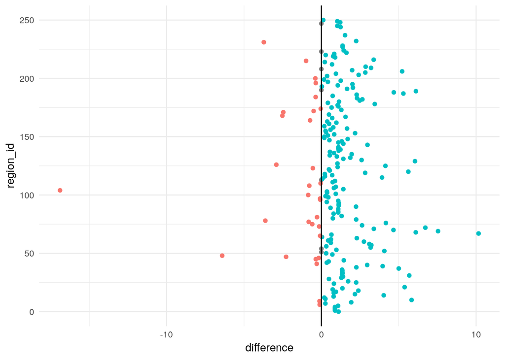